# Predict Bike Sharing Demand with AutoGluon Template

## Project: Predict Bike Sharing Demand with AutoGluon

This notebook is a template with each step that you need to complete for the project.

Please fill in your code where there are explicit `?` markers in the notebook. You are welcome to add more cells and code as you see fit.

Once you have completed all the code implementations, please export your notebook as a HTML file so the reviews can view your code. Make sure you have all outputs correctly outputted.

`File-> Export Notebook As... -> Export Notebook as HTML`

There is a writeup to complete as well after all code implememtation is done. Please answer all questions and attach the necessary tables and charts. You can complete the writeup in either markdown or PDF.

Completing the code template and writeup template will cover all of the rubric points for this project.

The rubric contains "Stand Out Suggestions" for enhancing the project beyond the minimum requirements. The stand out suggestions are optional. If you decide to pursue the "stand out suggestions", you can include the code in this notebook and also discuss the results in the writeup file.

## Step 1: Create an account with Kaggle

### Create Kaggle Account and download API key

Below is example of steps to get the API username and key. Each student will have their own username and key.

1. Open account settings.

2. Scroll down to API and click Create New API Token.

3. Open up `kaggle.json` and use the username and key.


## Step 2: Download the Kaggle dataset using the kaggle python library

### Open up Sagemaker Studio and use starter template

1. Notebook should be using a `ml.t3.medium` instance (2 vCPU + 4 GiB)
2. Notebook should be using kernal: `Python 3 (MXNet 1.8 Python 3.7 CPU Optimized)`

### Install packages

```python
!pip install -U pip
!pip install -U setuptools wheel
!pip install -U "mxnet<2.0.0" bokeh==2.0.1
!pip install autogluon --no-cache-dir
# Without --no-cache-dir, smaller aws instances may have trouble installing
```

[output not shown]

### Setup Kaggle API Key

```python
# create the .kaggle directory and an empty kaggle.json file
!mkdir -p /root/.kaggle
!touch /root/.kaggle/kaggle.json
!chmod 600 /root/.kaggle/kaggle.json
```

```python
pip install kaggle
```

```
WARNING: Running pip as the 'root' user can result in broken permissions and conflicting behaviour with the system package manager. It is recommended to use a virtual environment instead: https://pip.pypa.io/warnings/venv
```

```python
# Fill in your user name and key from creating the kaggle account and API token file
import json
kaggle_username = "muhammadumarfarrukh"
kaggle_key = "4ab38f6f12491e8aace852a046df8932"

# Save API token the kaggle.json file
with open("/root/.kaggle/kaggle.json", "w") as f:
    f.write(json.dumps({"username": kaggle_username, "key": kaggle_key}))
```

### Download and explore dataset

### Go to the bike sharing demand competition and agree to the terms

```python
# Download the dataset, it will be in a .zip file so you'll need to unzip it as well.
!kaggle competitions download -c bike-sharing-demand
# If you already downloaded it you can use the -o command to overwrite the file
!unzip -o bike-sharing-demand.zip
```

```
bike-sharing-demand.zip: Skipping, found more recently modified local copy (use --force to force download)
Archive:  bike-sharing-demand.zip
  inflating: sampleSubmission.csv
  inflating: test.csv
  inflating: train.csv
```

```python
import pandas as pd
from autogluon.tabular import TabularPredictor
```

```python
# Create the train dataset in pandas by reading the csv
# Set the parsing of the datetime column so you can use some of the `dt` features in pandas later
train = pd.read_csv("train.csv")
train.head()
```

|  | datetime | season | holiday | workingday | weather | temp | atemp | humidity | windspeed | casual | registered | count |
| --- | --- | --- | --- | --- | --- | --- | --- | --- | --- | --- | --- | --- |
| 0 | 2011-01-01 00:00:00 | 1 | 0 | 0 | 1 | 9.84 | 14.395 | 81 | 0.0 | 3 | 13 | 16 |
| 1 | 2011-01-01 01:00:00 | 1 | 0 | 0 | 1 | 9.02 | 13.635 | 80 | 0.0 | 8 | 32 | 40 |
| 2 | 2011-01-01 02:00:00 | 1 | 0 | 0 | 1 | 9.02 | 13.635 | 80 | 0.0 | 5 | 27 | 32 |
| 3 | 2011-01-01 03:00:00 | 1 | 0 | 0 | 1 | 9.84 | 14.395 | 75 | 0.0 | 3 | 10 | 13 |
| 4 | 2011-01-01 04:00:00 | 1 | 0 | 0 | 1 | 9.84 | 14.395 | 75 | 0.0 | 0 | 1 | 1 |

```python
#checking for null values but wont be converting the datetime
train.info()
```

```
<class 'pandas.core.frame.DataFrame'>
RangeIndex: 10886 entries, 0 to 10885
Data columns (total 12 columns):
 #   Column      Non-Null Count  Dtype
---  ------      --------------  -----
 0   datetime    10886 non-null  object
 1   season      10886 non-null  int64
 2   holiday     10886 non-null  int64
 3   workingday  10886 non-null  int64
 4   weather     10886 non-null  int64
 5   temp        10886 non-null  float64
 6   atemp       10886 non-null  float64
 7   humidity    10886 non-null  int64
 8   windspeed   10886 non-null  float64
 9   casual      10886 non-null  int64
 10  registered  10886 non-null  int64
 11  count       10886 non-null  int64
dtypes: float64(3), int64(8), object(1)
memory usage: 1020.7+ KB
```

```python
# train = train.drop(['casual','registered'],axis=1)
```

```python
train.head()
```

|  | datetime | season | holiday | workingday | weather | temp | atemp | humidity | windspeed | casual | registered | count |
| --- | --- | --- | --- | --- | --- | --- | --- | --- | --- | --- | --- | --- |
| 0 | 2011-01-01 00:00:00 | 1 | 0 | 0 | 1 | 9.84 | 14.395 | 81 | 0.0 | 3 | 13 | 16 |
| 1 | 2011-01-01 01:00:00 | 1 | 0 | 0 | 1 | 9.02 | 13.635 | 80 | 0.0 | 8 | 32 | 40 |
| 2 | 2011-01-01 02:00:00 | 1 | 0 | 0 | 1 | 9.02 | 13.635 | 80 | 0.0 | 5 | 27 | 32 |
| 3 | 2011-01-01 03:00:00 | 1 | 0 | 0 | 1 | 9.84 | 14.395 | 75 | 0.0 | 3 | 10 | 13 |
| 4 | 2011-01-01 04:00:00 | 1 | 0 | 0 | 1 | 9.84 | 14.395 | 75 | 0.0 | 0 | 1 | 1 |

```python
# Simple output of the train dataset to view some of the min/max/varition of the dataset features.
```

```python
# Create the test pandas dataframe in pandas by reading the csv, remember to parse the datetime!
test = pd.read_csv("test.csv")
test.head()
```

|  | datetime | season | holiday | workingday | weather | temp | atemp | humidity | windspeed |
| --- | --- | --- | --- | --- | --- | --- | --- | --- | --- |
| 0 | 2011-01-20 00:00:00 | 1 | 0 | 1 | 1 | 10.66 | 11.365 | 56 | 26.0027 |
| 1 | 2011-01-20 01:00:00 | 1 | 0 | 1 | 1 | 10.66 | 13.635 | 56 | 0.0000 |
| 2 | 2011-01-20 02:00:00 | 1 | 0 | 1 | 1 | 10.66 | 13.635 | 56 | 0.0000 |
| 3 | 2011-01-20 03:00:00 | 1 | 0 | 1 | 1 | 10.66 | 12.880 | 56 | 11.0014 |
| 4 | 2011-01-20 04:00:00 | 1 | 0 | 1 | 1 | 10.66 | 12.880 | 56 | 11.0014 |

```python
# Same thing as train and test dataset
submission = pd.read_csv("sampleSubmission.csv")
submission.head()
```

|  | datetime | count |
| --- | --- | --- |
| 0 | 2011-01-20 00:00:00 | 0 |
| 1 | 2011-01-20 01:00:00 | 0 |
| 2 | 2011-01-20 02:00:00 | 0 |
| 3 | 2011-01-20 03:00:00 | 0 |
| 4 | 2011-01-20 04:00:00 | 0 |

## Step 3: Train a model using AutoGluon’s Tabular Prediction

Requirements:

- We are prediting `count`, so it is the label we are setting.
- Ignore `casual` and `registered` columns as they are also not present in the test dataset.
- Use the `root_mean_squared_error` as the metric to use for evaluation.
- Set a time limit of 10 minutes (600 seconds).
- Use the preset `best_quality` to focus on creating the best model.

```python
predictor = TabularPredictor(label="count", problem_type="regression", eval_metric="root_mean_squared_error",
                             learner_kwargs={
                                 "ignored_columns":["casual", "registered"]}).fit(train_data=train,
                                                                                  time_limit=600,
                                                                                  presets="best_quality")
```

[output not shown]

[output cut: 980 more lines]

```
	-53.2362	 = Validation score   (-root_mean_squared_error)
	41.89s	 = Training   runtime
	0.88s	 = Validation runtime
Fitting model: CatBoost_BAG_L2 ... Training model for up to 55.2s of the 55.14s of remaining time.
	Fitting 8 child models (S1F1 - S1F8) | Fitting with ParallelLocalFoldFittingStrategy (2 workers, per: cpus=1, gpus=0, memory=0.93%)
	-55.3294	 = Validation score   (-root_mean_squared_error)
	56.53s	 = Training   runtime
	0.08s	 = Validation runtime
Fitting model: WeightedEnsemble_L3 ... Training model for up to 360.0s of the -7.02s of remaining time.
	Ensemble Weights: {'RandomForestMSE_BAG_L2': 0.741, 'CatBoost_BAG_L2': 0.259}
	-52.9398	 = Validation score   (-root_mean_squared_error)
	0.45s	 = Training   runtime
	0.0s	 = Validation runtime
AutoGluon training complete, total runtime = 450.71s ... Best model: "WeightedEnsemble_L3"
TabularPredictor saved. To load, use: predictor = TabularPredictor.load("AutogluonModels/ag-20240201_211255")
```

### Review AutoGluon's training run with ranking of models that did the best.

```python
predictor.fit_summary()
```

```
*** Summary of fit() ***
Estimated performance of each model:
                    model   score_val              eval_metric  pred_time_val    fit_time  pred_time_val_marginal  fit_time_marginal  stack_level  can_infer  fit_order
0     WeightedEnsemble_L3  -52.939843  root_mean_squared_error       3.306552  399.940161                0.000702           0.450098            3       True         10
1  RandomForestMSE_BAG_L2  -53.236241  root_mean_squared_error       3.227306  342.958278                0.878475          41.890677            2       True          8
2         CatBoost_BAG_L2  -55.329414  root_mean_squared_error       2.427375  357.599385                0.078545          56.531785            2       True          9
3   KNeighborsDist_BAG_L1  -84.125061  root_mean_squared_error       0.076818    0.041185                0.076818           0.041185            1       True          2
4     WeightedEnsemble_L2  -84.125061  root_mean_squared_error       0.077643    0.426595                0.000824           0.385411            2       True          7
5   KNeighborsUnif_BAG_L1 -101.546199  root_mean_squared_error       0.069275    0.075827                0.069275           0.075827            1       True          1
6  RandomForestMSE_BAG_L1 -116.548359  root_mean_squared_error       0.997033   18.563696                0.997033          18.563696            1       True          3
7    ExtraTreesMSE_BAG_L1 -124.600676  root_mean_squared_error       0.658079    8.176450                0.658079           8.176450            1       True          5
8         CatBoost_BAG_L1 -130.597016  root_mean_squared_error       0.126645  209.815058                0.126645         209.815058            1       True          4
9  NeuralNetFastAI_BAG_L1 -140.508791  root_mean_squared_error       0.420981   64.395385                0.420981          64.395385            1       True          6
Number of models trained: 10
Types of models trained:
{'StackerEnsembleModel_KNN', 'StackerEnsembleModel_NNFastAiTabular', 'WeightedEnsembleModel', 'StackerEnsembleModel_CatBoost', 'StackerEnsembleModel_XT', 'StackerEnsembleModel_RF'}
Bagging used: True  (with 8 folds)
Multi-layer stack-ensembling used: True  (with 3 levels)
Feature Metadata (Processed):
(raw dtype, special dtypes):
('float', [])                : 3 | ['temp', 'atemp', 'windspeed']
('int', [])                  : 3 | ['season', 'weather', 'humidity']
('int', ['bool'])            : 2 | ['holiday', 'workingday']
('int', ['datetime_as_int']) : 5 | ['datetime', 'datetime.year', 'datetime.month', 'datetime.day', 'datetime.dayofweek']
*** End of fit() summary ***
```

[output not shown]

[output cut: 78 more lines]

```
 7    8.176450                0.658079           8.176450            1
 8  209.815058                0.126645         209.815058            1
 9   64.395385                0.420981          64.395385            1

    can_infer  fit_order
 0       True         10
 1       True          8
 2       True          9
 3       True          2
 4       True          7
 5       True          1
 6       True          3
 7       True          5
 8       True          4
 9       True          6  }
```

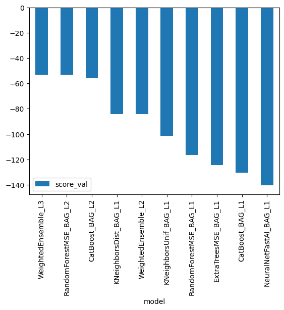

```python
predictor.leaderboard(silent=True).plot(kind="bar", x="model", y="score_val")
```

### Create predictions from test dataset

```python
predicted_y = predictor.predict(test)
```

```python
predicted_y
```

```
0        23.283936
1        43.542381
2        46.694958
3        48.822964
4        51.368378
           ...
6488    154.171906
6489    154.196609
6490    153.099487
6491    151.864655
6492    147.976395
Name: count, Length: 6493, dtype: float32
```

```python
test['count'] = predicted_y
```

```python
predictions = predictor.evaluate(test)
```

```python
predictions
```

```
{'root_mean_squared_error': -0.0,
 'mean_squared_error': -0.0,
 'mean_absolute_error': -0.0,
 'r2': 1.0,
 'pearsonr': 1.0,
 'median_absolute_error': -0.0}
```

#### NOTE: Kaggle will reject the submission if we don't set everything to be > 0.

```python
# Describe the `predictions` series to see if there are any negative values
test.describe()
```

|  | season | holiday | workingday | weather | temp | atemp | humidity | windspeed | count |
| --- | --- | --- | --- | --- | --- | --- | --- | --- | --- |
| count | 6493.000000 | 6493.000000 | 6493.000000 | 6493.000000 | 6493.000000 | 6493.000000 | 6493.000000 | 6493.000000 | 6493.000000 |
| mean | 2.493300 | 0.029108 | 0.685815 | 1.436778 | 20.620607 | 24.012865 | 64.125212 | 12.631157 | 101.138809 |
| std | 1.091258 | 0.168123 | 0.464226 | 0.648390 | 8.059583 | 8.782741 | 19.293391 | 8.250151 | 90.078186 |
| min | 1.000000 | 0.000000 | 0.000000 | 1.000000 | 0.820000 | 0.000000 | 16.000000 | 0.000000 | 2.587630 |
| 25% | 2.000000 | 0.000000 | 0.000000 | 1.000000 | 13.940000 | 16.665000 | 49.000000 | 7.001500 | 20.294537 |
| 50% | 3.000000 | 0.000000 | 1.000000 | 1.000000 | 21.320000 | 25.000000 | 65.000000 | 11.001400 | 64.342270 |
| 75% | 3.000000 | 0.000000 | 1.000000 | 2.000000 | 27.060000 | 31.060000 | 81.000000 | 16.997900 | 165.467422 |
| max | 4.000000 | 1.000000 | 1.000000 | 4.000000 | 40.180000 | 50.000000 | 100.000000 | 55.998600 | 364.800079 |

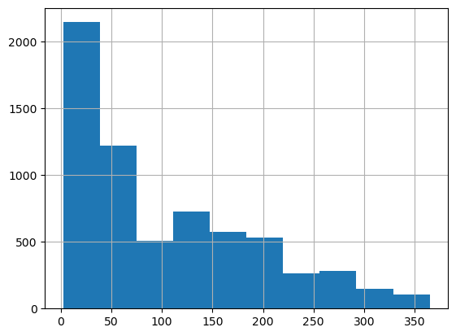

```python
# How many negative values do we have?
test['count'].hist()
```

```python
# Set them to zero
# we dont have any negative values but for future running this should work
count_negatives = 0
for i in range(len(predicted_y)):
    if predicted_y[i]<0:
        predicted_y[i] = 0
        count_negatives += 1
    else:
        pass
print("Negative Values Convered to zero: ",count_negatives)
```

```
Negative Values Convered to zero:  0
```

### Set predictions to submission dataframe, save, and submit

```python
submission["count"] = predicted_y
submission.to_csv("submission.csv", index=False)
```

```python
submission.describe()
```

|  | count |
| --- | --- |
| count | 6493.000000 |
| mean | 101.138809 |
| std | 90.078186 |
| min | 2.587630 |
| 25% | 20.294537 |
| 50% | 64.342270 |
| 75% | 165.467422 |
| max | 364.800079 |

```python
submission.head()
```

|  | datetime | count |
| --- | --- | --- |
| 0 | 2011-01-20 00:00:00 | 23.283936 |
| 1 | 2011-01-20 01:00:00 | 43.542381 |
| 2 | 2011-01-20 02:00:00 | 46.694958 |
| 3 | 2011-01-20 03:00:00 | 48.822964 |
| 4 | 2011-01-20 04:00:00 | 51.368378 |

```python
!kaggle competitions submit -c bike-sharing-demand -f submission.csv -m "first raw submission"
```

```
Successfully submitted to Bike Sharing Demand
```

```python
!kaggle competitions submit -c bike-sharing-demand -f submission.csv -m "third raw submission"
```

```
Successfully submitted to Bike Sharing Demand
```

#### View submission via the command line or in the web browser under the competition's page - `My Submissions`

```python
!kaggle competitions submissions -c bike-sharing-demand | tail -n +1 | head -n 6
```

```
fileName        date                 description           status    publicScore  privateScore
--------------  -------------------  --------------------  --------  -----------  ------------
submission.csv  2024-01-31 15:46:43  first raw submission  complete  1.79413      1.79413
submission.csv  2024-01-31 14:50:26  first raw submission  complete  1.80047      1.80047
```

```python
!kaggle competitions submissions -c bike-sharing-demand | tail -n +1 | head -n 6
```

```
fileName                     date                 description                            status    publicScore  privateScore
---------------------------  -------------------  -------------------------------------  --------  -----------  ------------
submission.csv               2024-02-01 21:24:42  third raw submission                   complete  1.78742      1.78742
submission_new_hpo_2.csv     2024-02-01 15:31:48  new submission with hyperparameters 3  complete  0.58809      0.58809
submission_new_hpo_2.csv     2024-02-01 15:12:40  new submission with hyperparameters 3  complete  0.725        0.725
submission_new_hpo_2.csv     2024-02-01 14:42:05  new submission with hyperparameters 3  complete  0.62671      0.62671
```

#### Initial score of 1.79413

## Step 4: Exploratory Data Analysis and Creating an additional feature

- Any additional feature will do, but a great suggestion would be to separate out the datetime into hour, day, or month parts.

```
array([[<AxesSubplot:title={'center':'season'}>,
        <AxesSubplot:title={'center':'holiday'}>,
        <AxesSubplot:title={'center':'workingday'}>],
       [<AxesSubplot:title={'center':'weather'}>,
        <AxesSubplot:title={'center':'temp'}>,
        <AxesSubplot:title={'center':'atemp'}>],
       [<AxesSubplot:title={'center':'humidity'}>,
        <AxesSubplot:title={'center':'windspeed'}>,
        <AxesSubplot:title={'center':'casual'}>],
       [<AxesSubplot:title={'center':'registered'}>,
        <AxesSubplot:title={'center':'count'}>, <AxesSubplot:>]],
      dtype=object)
```

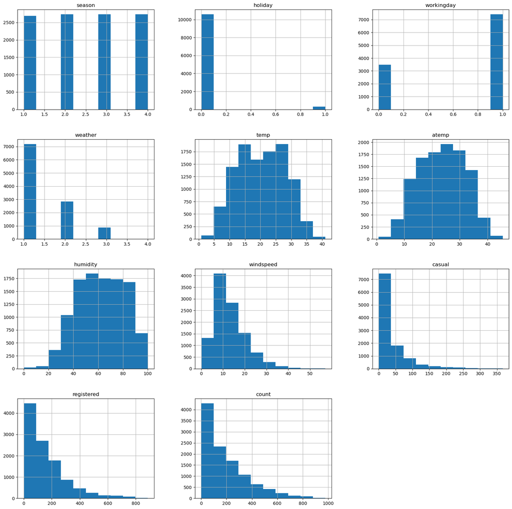

```python
# Create a histogram of all features to show the distribution of each one relative to the data. This is part of the exploritory data analysis
train.hist(figsize=(20,20))
```

```python
train.head()
```

|  | datetime | season | holiday | workingday | weather | temp | atemp | humidity | windspeed | casual | registered | count |
| --- | --- | --- | --- | --- | --- | --- | --- | --- | --- | --- | --- | --- |
| 0 | 2011-01-01 00:00:00 | 1 | 0 | 0 | 1 | 9.84 | 14.395 | 81 | 0.0 | 3 | 13 | 16 |
| 1 | 2011-01-01 01:00:00 | 1 | 0 | 0 | 1 | 9.02 | 13.635 | 80 | 0.0 | 8 | 32 | 40 |
| 2 | 2011-01-01 02:00:00 | 1 | 0 | 0 | 1 | 9.02 | 13.635 | 80 | 0.0 | 5 | 27 | 32 |
| 3 | 2011-01-01 03:00:00 | 1 | 0 | 0 | 1 | 9.84 | 14.395 | 75 | 0.0 | 3 | 10 | 13 |
| 4 | 2011-01-01 04:00:00 | 1 | 0 | 0 | 1 | 9.84 | 14.395 | 75 | 0.0 | 0 | 1 | 1 |

```python
train['datetime'] =  pd.to_datetime(train['datetime'])
```

```python
# create a new feature , will not extract minute or seconds as that is absolute here
train["day"] = train.datetime.dt.dayofweek
train["month"] = train.datetime.dt.month
train["year"] = train.datetime.dt.year
train["hour"] = train.datetime.dt.hour
train = train.drop(["datetime"],axis=1)
train.head(n=20)
```

|  | season | holiday | workingday | weather | temp | atemp | humidity | windspeed | casual | registered | count | day | month | year | hour |
| --- | --- | --- | --- | --- | --- | --- | --- | --- | --- | --- | --- | --- | --- | --- | --- |
| 0 | 1 | 0 | 0 | 1 | 9.84 | 14.395 | 81 | 0.0000 | 3 | 13 | 16 | 5 | 1 | 2011 | 0 |
| 1 | 1 | 0 | 0 | 1 | 9.02 | 13.635 | 80 | 0.0000 | 8 | 32 | 40 | 5 | 1 | 2011 | 1 |
| 2 | 1 | 0 | 0 | 1 | 9.02 | 13.635 | 80 | 0.0000 | 5 | 27 | 32 | 5 | 1 | 2011 | 2 |
| 3 | 1 | 0 | 0 | 1 | 9.84 | 14.395 | 75 | 0.0000 | 3 | 10 | 13 | 5 | 1 | 2011 | 3 |
| 4 | 1 | 0 | 0 | 1 | 9.84 | 14.395 | 75 | 0.0000 | 0 | 1 | 1 | 5 | 1 | 2011 | 4 |
| 5 | 1 | 0 | 0 | 2 | 9.84 | 12.880 | 75 | 6.0032 | 0 | 1 | 1 | 5 | 1 | 2011 | 5 |
| 6 | 1 | 0 | 0 | 1 | 9.02 | 13.635 | 80 | 0.0000 | 2 | 0 | 2 | 5 | 1 | 2011 | 6 |
| 7 | 1 | 0 | 0 | 1 | 8.20 | 12.880 | 86 | 0.0000 | 1 | 2 | 3 | 5 | 1 | 2011 | 7 |
| 8 | 1 | 0 | 0 | 1 | 9.84 | 14.395 | 75 | 0.0000 | 1 | 7 | 8 | 5 | 1 | 2011 | 8 |
| 9 | 1 | 0 | 0 | 1 | 13.12 | 17.425 | 76 | 0.0000 | 8 | 6 | 14 | 5 | 1 | 2011 | 9 |
| 10 | 1 | 0 | 0 | 1 | 15.58 | 19.695 | 76 | 16.9979 | 12 | 24 | 36 | 5 | 1 | 2011 | 10 |
| 11 | 1 | 0 | 0 | 1 | 14.76 | 16.665 | 81 | 19.0012 | 26 | 30 | 56 | 5 | 1 | 2011 | 11 |
| 12 | 1 | 0 | 0 | 1 | 17.22 | 21.210 | 77 | 19.0012 | 29 | 55 | 84 | 5 | 1 | 2011 | 12 |
| 13 | 1 | 0 | 0 | 2 | 18.86 | 22.725 | 72 | 19.9995 | 47 | 47 | 94 | 5 | 1 | 2011 | 13 |
| 14 | 1 | 0 | 0 | 2 | 18.86 | 22.725 | 72 | 19.0012 | 35 | 71 | 106 | 5 | 1 | 2011 | 14 |
| 15 | 1 | 0 | 0 | 2 | 18.04 | 21.970 | 77 | 19.9995 | 40 | 70 | 110 | 5 | 1 | 2011 | 15 |
| 16 | 1 | 0 | 0 | 2 | 17.22 | 21.210 | 82 | 19.9995 | 41 | 52 | 93 | 5 | 1 | 2011 | 16 |
| 17 | 1 | 0 | 0 | 2 | 18.04 | 21.970 | 82 | 19.0012 | 15 | 52 | 67 | 5 | 1 | 2011 | 17 |
| 18 | 1 | 0 | 0 | 3 | 17.22 | 21.210 | 88 | 16.9979 | 9 | 26 | 35 | 5 | 1 | 2011 | 18 |
| 19 | 1 | 0 | 0 | 3 | 17.22 | 21.210 | 88 | 16.9979 | 6 | 31 | 37 | 5 | 1 | 2011 | 19 |

```python
test.head()
```

|  | datetime | season | holiday | workingday | weather | temp | atemp | humidity | windspeed |
| --- | --- | --- | --- | --- | --- | --- | --- | --- | --- |
| 0 | 2011-01-20 00:00:00 | 1 | 0 | 1 | 1 | 10.66 | 11.365 | 56 | 26.0027 |
| 1 | 2011-01-20 01:00:00 | 1 | 0 | 1 | 1 | 10.66 | 13.635 | 56 | 0.0000 |
| 2 | 2011-01-20 02:00:00 | 1 | 0 | 1 | 1 | 10.66 | 13.635 | 56 | 0.0000 |
| 3 | 2011-01-20 03:00:00 | 1 | 0 | 1 | 1 | 10.66 | 12.880 | 56 | 11.0014 |
| 4 | 2011-01-20 04:00:00 | 1 | 0 | 1 | 1 | 10.66 | 12.880 | 56 | 11.0014 |

```python
test['datetime'] =  pd.to_datetime(test['datetime'])
test["day"] = test.datetime.dt.dayofweek
test["month"] = test.datetime.dt.month
test["year"] = test.datetime.dt.year
test["hour"] = test.datetime.dt.hour
test = test.drop(["datetime"],axis=1)
```

## Make category types for these so models know they are not just numbers

- AutoGluon originally sees these as ints, but in reality they are int representations of a category.
- Setting the dtype to category will classify these as categories in AutoGluon.

```python
train["season"] = train["season"].astype("category")
train["weather"] = train["weather"].astype("category")
test["season"] = test["season"].astype("category")
test["weather"] = test["season"].astype("category")
```

```python
train.info()
```

```
<class 'pandas.core.frame.DataFrame'>
RangeIndex: 10886 entries, 0 to 10885
Data columns (total 15 columns):
 #   Column      Non-Null Count  Dtype
---  ------      --------------  -----
 0   season      10886 non-null  category
 1   holiday     10886 non-null  int64
 2   workingday  10886 non-null  int64
 3   weather     10886 non-null  category
 4   temp        10886 non-null  float64
 5   atemp       10886 non-null  float64
 6   humidity    10886 non-null  int64
 7   windspeed   10886 non-null  float64
 8   casual      10886 non-null  int64
 9   registered  10886 non-null  int64
 10  count       10886 non-null  int64
 11  day         10886 non-null  int32
 12  month       10886 non-null  int32
 13  year        10886 non-null  int32
 14  hour        10886 non-null  int32
dtypes: category(2), float64(3), int32(4), int64(6)
memory usage: 957.3 KB
```

```python
test.info()
```

```
<class 'pandas.core.frame.DataFrame'>
RangeIndex: 6493 entries, 0 to 6492
Data columns (total 12 columns):
 #   Column      Non-Null Count  Dtype
---  ------      --------------  -----
 0   season      6493 non-null   category
 1   holiday     6493 non-null   int64
 2   workingday  6493 non-null   int64
 3   weather     6493 non-null   category
 4   temp        6493 non-null   float64
 5   atemp       6493 non-null   float64
 6   humidity    6493 non-null   int64
 7   windspeed   6493 non-null   float64
 8   day         6493 non-null   int32
 9   month       6493 non-null   int32
 10  year        6493 non-null   int32
 11  hour        6493 non-null   int32
dtypes: category(2), float64(3), int32(4), int64(3)
memory usage: 419.0 KB
```

```python
# View are new feature
train.head()
```

|  | season | holiday | workingday | weather | temp | atemp | humidity | windspeed | casual | registered | count | day | month | year | hour |
| --- | --- | --- | --- | --- | --- | --- | --- | --- | --- | --- | --- | --- | --- | --- | --- |
| 0 | 1 | 0 | 0 | 1 | 9.84 | 14.395 | 81 | 0.0 | 3 | 13 | 16 | 5 | 1 | 2011 | 0 |
| 1 | 1 | 0 | 0 | 1 | 9.02 | 13.635 | 80 | 0.0 | 8 | 32 | 40 | 5 | 1 | 2011 | 1 |
| 2 | 1 | 0 | 0 | 1 | 9.02 | 13.635 | 80 | 0.0 | 5 | 27 | 32 | 5 | 1 | 2011 | 2 |
| 3 | 1 | 0 | 0 | 1 | 9.84 | 14.395 | 75 | 0.0 | 3 | 10 | 13 | 5 | 1 | 2011 | 3 |
| 4 | 1 | 0 | 0 | 1 | 9.84 | 14.395 | 75 | 0.0 | 0 | 1 | 1 | 5 | 1 | 2011 | 4 |

```
array([[<AxesSubplot:title={'center':'holiday'}>,
        <AxesSubplot:title={'center':'workingday'}>,
        <AxesSubplot:title={'center':'temp'}>,
        <AxesSubplot:title={'center':'atemp'}>],
       [<AxesSubplot:title={'center':'humidity'}>,
        <AxesSubplot:title={'center':'windspeed'}>,
        <AxesSubplot:title={'center':'casual'}>,
        <AxesSubplot:title={'center':'registered'}>],
       [<AxesSubplot:title={'center':'count'}>,
        <AxesSubplot:title={'center':'day'}>,
        <AxesSubplot:title={'center':'month'}>,
        <AxesSubplot:title={'center':'year'}>],
       [<AxesSubplot:title={'center':'hour'}>, <AxesSubplot:>,
        <AxesSubplot:>, <AxesSubplot:>]], dtype=object)
```

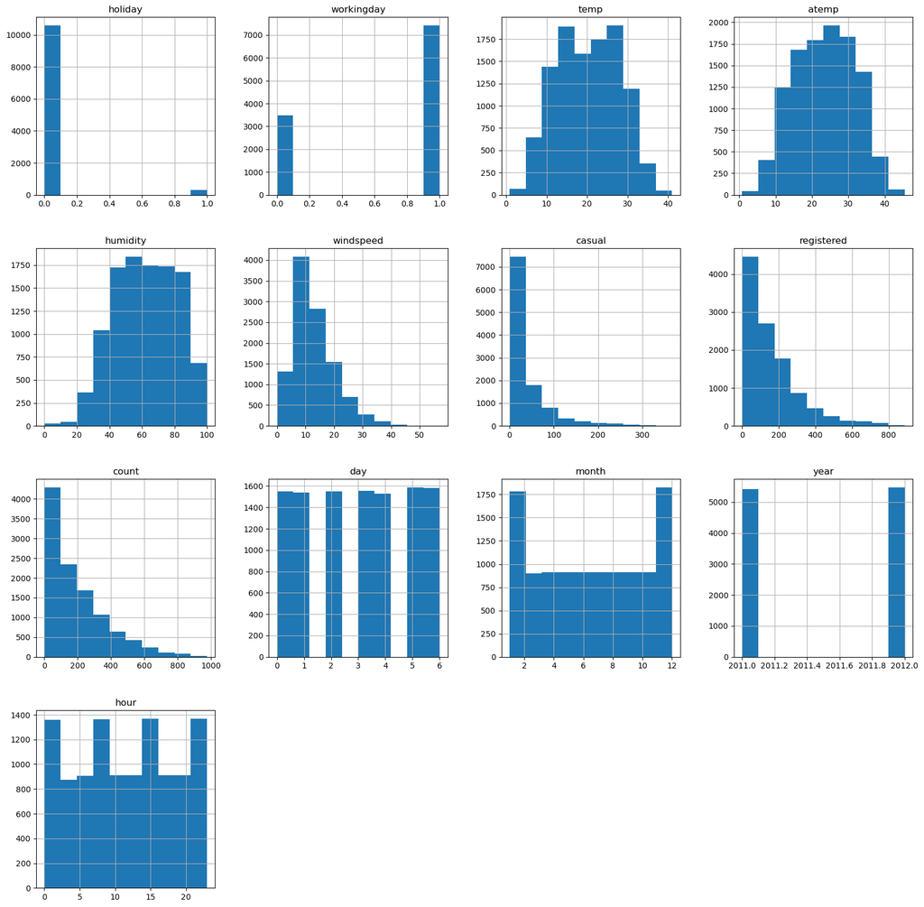

```python
# View histogram of all features again now with the hour feature
train.hist(figsize=(20,20))
```

## Step 5: Rerun the model with the same settings as before, just with more features

```python
predictor_new_features = TabularPredictor(label="count", problem_type="regression", eval_metric="root_mean_squared_error",
                             learner_kwargs={
                                 "ignored_columns":["casual", "registered"]}).fit(train_data=train,
                                                                                  time_limit=600,
                                                                                  presets="best_quality")
```

[output not shown]

[output cut: 470 more lines]

```
	-35.8217	 = Validation score   (-root_mean_squared_error)
	31.51s	 = Training   runtime
	0.77s	 = Validation runtime
Fitting model: CatBoost_BAG_L2 ... Training model for up to 56.1s of the 56.03s of remaining time.
	Fitting 8 child models (S1F1 - S1F8) | Fitting with ParallelLocalFoldFittingStrategy (2 workers, per: cpus=1, gpus=0, memory=0.75%)
	-35.1648	 = Validation score   (-root_mean_squared_error)
	58.79s	 = Training   runtime
	0.11s	 = Validation runtime
Fitting model: WeightedEnsemble_L3 ... Training model for up to 360.0s of the -9.83s of remaining time.
	Ensemble Weights: {'CatBoost_BAG_L2': 0.42, 'CatBoost_BAG_L1': 0.3, 'RandomForestMSE_BAG_L2': 0.22, 'ExtraTreesMSE_BAG_L1': 0.06}
	-34.7813	 = Validation score   (-root_mean_squared_error)
	0.53s	 = Training   runtime
	0.0s	 = Validation runtime
AutoGluon training complete, total runtime = 432.59s ... Best model: "WeightedEnsemble_L3"
TabularPredictor saved. To load, use: predictor = TabularPredictor.load("AutogluonModels/ag-20240201_212517")
```

```python
predictor_new_features.fit_summary()
```

```
*** Summary of fit() ***
Estimated performance of each model:
                    model   score_val              eval_metric  pred_time_val    fit_time  pred_time_val_marginal  fit_time_marginal  stack_level  can_infer  fit_order
0     WeightedEnsemble_L3  -34.781324  root_mean_squared_error       4.017453  378.102677                0.000713           0.531126            3       True         10
1         CatBoost_BAG_L2  -35.164830  root_mean_squared_error       3.243209  346.057306                0.110442          58.785338            2       True          9
2     WeightedEnsemble_L2  -35.201341  root_mean_squared_error       1.876389  236.588340                0.000950           0.434470            2       True          7
3  RandomForestMSE_BAG_L2  -35.821672  root_mean_squared_error       3.906298  318.786213                0.773530          31.514245            2       True          8
4         CatBoost_BAG_L1  -35.874815  root_mean_squared_error       0.210607  215.193020                0.210607         215.193020            1       True          4
5    ExtraTreesMSE_BAG_L1  -39.013826  root_mean_squared_error       0.761615    6.264771                0.761615           6.264771            1       True          5
6  RandomForestMSE_BAG_L1  -39.566080  root_mean_squared_error       0.903217   14.696078                0.903217          14.696078            1       True          3
7   KNeighborsDist_BAG_L1 -112.157112  root_mean_squared_error       0.177808    0.063647                0.177808           0.063647            1       True          2
8  NeuralNetFastAI_BAG_L1 -114.961729  root_mean_squared_error       0.825492   51.001877                0.825492          51.001877            1       True          6
9   KNeighborsUnif_BAG_L1 -115.733231  root_mean_squared_error       0.254028    0.052576                0.254028           0.052576            1       True          1
Number of models trained: 10
Types of models trained:
{'StackerEnsembleModel_KNN', 'StackerEnsembleModel_NNFastAiTabular', 'WeightedEnsembleModel', 'StackerEnsembleModel_CatBoost', 'StackerEnsembleModel_XT', 'StackerEnsembleModel_RF'}
Bagging used: True  (with 8 folds)
Multi-layer stack-ensembling used: True  (with 3 levels)
Feature Metadata (Processed):
(raw dtype, special dtypes):
('category', [])  : 2 | ['season', 'weather']
('float', [])     : 3 | ['temp', 'atemp', 'windspeed']
('int', [])       : 4 | ['humidity', 'day', 'month', 'hour']
('int', ['bool']) : 3 | ['holiday', 'workingday', 'year']
*** End of fit() summary ***
```

[output not shown]

[output cut: 78 more lines]

```
 7    0.063647                0.177808           0.063647            1
 8   51.001877                0.825492          51.001877            1
 9    0.052576                0.254028           0.052576            1

    can_infer  fit_order
 0       True         10
 1       True          9
 2       True          7
 3       True          8
 4       True          4
 5       True          5
 6       True          3
 7       True          2
 8       True          6
 9       True          1  }
```

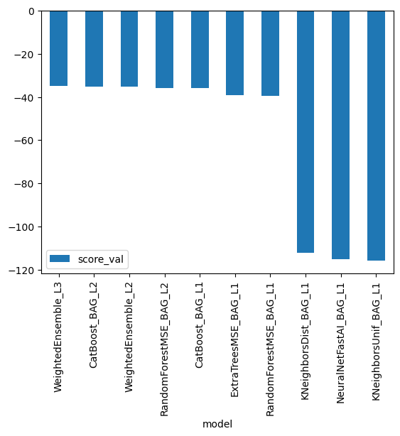

```python
predictor_new_features.leaderboard(silent=True).plot(kind="bar", x="model", y="score_val")
```

```python
# Remember to set all negative values to zero
test.drop(["count"],axis=1)
predictions_new = predictor_new_features.predict(test)
predictions_new.head()
```

```
0    13.482455
1     5.119851
2     3.307714
3     2.523064
4     2.456153
Name: count, dtype: float32
```

```python
test.shape
```

```
(6493, 13)
```

```python
predictions_new
```

```
0        13.482455
1         5.119851
2         3.307714
3         2.523064
4         2.456153
           ...
6488    347.342773
6489    228.708160
6490    164.524292
6491    114.791580
6492     64.118584
Name: count, Length: 6493, dtype: float32
```

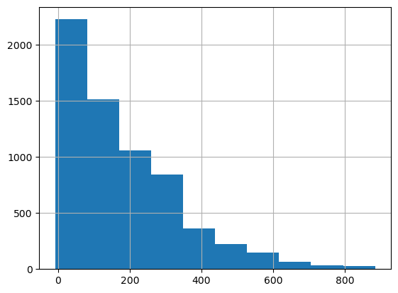

```python
predictions_new.hist()
```

```python
count_negatives = 0
for i in range(len(predictions_new)):
    if predictions_new[i]<0:
        predictions_new[i] = 0
        count_negatives += 1
    else:
        pass
print("Negative Values Convered to zero: ",count_negatives)
```

```
Negative Values Convered to zero:  155
```

```python
predictions_new.describe()
```

```
count    6493.000000
mean      177.165314
std       162.378937
min         0.000000
25%        43.795898
50%       138.670395
75%       264.561737
max       884.318420
Name: count, dtype: float64
```

```python
# Same submitting predictions
submission_new_features = pd.read_csv("sampleSubmission.csv")
submission_new_features["count"] = predictions_new
submission_new_features.to_csv("submission_new_features.csv", index=False)
```

```python
submission_new_features
```

|  | datetime | count |
| --- | --- | --- |
| 0 | 2011-01-20 00:00:00 | 13.482455 |
| 1 | 2011-01-20 01:00:00 | 5.119851 |
| 2 | 2011-01-20 02:00:00 | 3.307714 |
| 3 | 2011-01-20 03:00:00 | 2.523064 |
| 4 | 2011-01-20 04:00:00 | 2.456153 |
| ... | ... | ... |
| 6488 | 2012-12-31 19:00:00 | 347.342773 |
| 6489 | 2012-12-31 20:00:00 | 228.708160 |
| 6490 | 2012-12-31 21:00:00 | 164.524292 |
| 6491 | 2012-12-31 22:00:00 | 114.791580 |
| 6492 | 2012-12-31 23:00:00 | 64.118584 |

6493 rows × 2 columns

```python
!kaggle competitions submit -c bike-sharing-demand -f submission_new_features.csv -m "new features"
```

```
Successfully submitted to Bike Sharing Demand
```

```python
!kaggle competitions submit -c bike-sharing-demand -f submission_new_features.csv -m "new features submission 2 re running the whole notebook"
```

```
Successfully submitted to Bike Sharing Demand
```

```python
!kaggle competitions submissions -c bike-sharing-demand | tail -n +1 | head -n 8
```

```
fileName                     date                 description           status    publicScore  privateScore
---------------------------  -------------------  --------------------  --------  -----------  ------------
submission_new_features.csv  2024-01-31 16:08:54  new features          complete  0.61719      0.61719
submission_new_features.csv  2024-01-31 16:06:47  new features          error
submission_new_features.csv  2024-01-31 16:05:37  new features          error
submission_new_features.csv  2024-01-31 16:04:38  new features          error
submission.csv               2024-01-31 15:46:43  first raw submission  complete  1.79413      1.79413
submission.csv               2024-01-31 14:50:26  first raw submission  complete  1.80047      1.80047
```

```python
!kaggle competitions submissions -c bike-sharing-demand | tail -n +1 | head -n 8
```

```
fileName                     date                 description                                              status    publicScore  privateScore
---------------------------  -------------------  -------------------------------------------------------  --------  -----------  ------------
submission_new_features.csv  2024-02-01 21:35:39  new features submission 2 re running the whole notebook  complete  0.61574      0.61574
submission.csv               2024-02-01 21:24:42  third raw submission                                     complete  1.78742      1.78742
submission_new_hpo_2.csv     2024-02-01 15:31:48  new submission with hyperparameters 3                    complete  0.58809      0.58809
submission_new_hpo_2.csv     2024-02-01 15:12:40  new submission with hyperparameters 3                    complete  0.725        0.725
submission_new_hpo_2.csv     2024-02-01 14:42:05  new submission with hyperparameters 3                    complete  0.62671      0.62671
submission_new_hpo_2.csv     2024-01-31 23:07:09  new submission with hyperparameters 3                    complete  0.62671      0.62671
```

#### New Score of 0.61719

## Step 6: Hyper parameter optimization

- There are many options for hyper parameter optimization.
- Options are to change the AutoGluon higher level parameters or the individual model hyperparameters.
- The hyperparameters of the models themselves that are in AutoGluon. Those need the `hyperparameter` and `hyperparameter_tune_kwargs` arguments.

```python
from autogluon.common import space


non_default_options = { 'num_epochs': 30,  'learning_rate': space.Real(1e-4, 1e-2, default=5e-3, log=True),  'activation': space.Categorical('relu', 'softrelu', 'tanh'),
'dropout_prob': space.Real(0.0, 0.5, default=0.1),}
GBM_options = {  'extra_trees': True,
                'num_boost_round': space.Int(lower=100, upper=800, default=100),
    'num_leaves': space.Int(lower=10, upper=110, default=40),
}
hyperparameters = {
                   'GBM': GBM_options,
                   'NN_TORCH': non_default_options,
                  }

hyperparameter_tune_kwargs = {
    'num_trials': 15,
    'scheduler' : 'local',
    'searcher': 'random',
}
```

```python
predictor_new_hpo = TabularPredictor(label="count", problem_type="regression", eval_metric="root_mean_squared_error",
                             learner_kwargs={
                                 "ignored_columns":["casual", "registered"]}
                                    ).fit(train_data=train,time_limit=600,presets="best_quality" ,hyperparameters=hyperparameters,
    hyperparameter_tune_kwargs=hyperparameter_tune_kwargs)
```

```
No model was trained during hyperparameter tuning NeuralNetTorch_BAG_L2... Skipping this model.
Fitting model: WeightedEnsemble_L3 ... Training model for up to 360.0s of the 43.75s of remaining time.
	Ensemble Weights: {'NeuralNetTorch_BAG_L1/68019_00000': 1.0}
	-43.5183	 = Validation score   (-root_mean_squared_error)
	0.01s	 = Training   runtime
	0.0s	 = Validation runtime
AutoGluon training complete, total runtime = 455.49s ... Best model: "WeightedEnsemble_L2"
TabularPredictor saved. To load, use: predictor = TabularPredictor.load("AutogluonModels/ag-20240201_214343")
```

```python
predictor_new_hpo.fit_summary()
```

```
*** Summary of fit() ***
Estimated performance of each model:
                               model  score_val              eval_metric  pred_time_val    fit_time  pred_time_val_marginal  fit_time_marginal  stack_level  can_infer  fit_order
0  NeuralNetTorch_BAG_L1/68019_00000 -43.518283  root_mean_squared_error       0.000153  120.285996                0.000153         120.285996            1       True          1
1                WeightedEnsemble_L3 -43.518283  root_mean_squared_error       0.001056  120.292180                0.000903           0.006184            3       True          3
2                WeightedEnsemble_L2 -43.518283  root_mean_squared_error       0.001168  120.291345                0.001015           0.005349            2       True          2
Number of models trained: 3
Types of models trained:
{'WeightedEnsembleModel', 'StackerEnsembleModel_TabularNeuralNetTorch'}
Bagging used: True  (with 8 folds)
Multi-layer stack-ensembling used: True  (with 3 levels)
Feature Metadata (Processed):
(raw dtype, special dtypes):
('category', [])  : 2 | ['season', 'weather']
('float', [])     : 3 | ['temp', 'atemp', 'windspeed']
('int', [])       : 4 | ['humidity', 'day', 'month', 'hour']
('int', ['bool']) : 3 | ['holiday', 'workingday', 'year']
*** End of fit() summary ***
```

[output not shown]

```python
predictor_new_hpo
```

```
<autogluon.tabular.predictor.predictor.TabularPredictor at 0x7f094f398ac0>
```

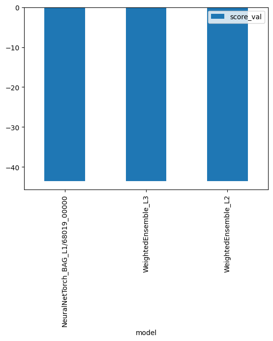

```python
predictor_new_hpo.leaderboard(silent=True).plot(kind="bar", x="model", y="score_val")
```

```python
# Remember to set all negative values to zero
predictor_new_hpo_count = predictor_new_hpo.predict(test)
predictor_new_hpo_count.head()

count_negatives = 0
for i in range(len(predictor_new_hpo_count)):
    if predictor_new_hpo_count[i]<0:
        predictor_new_hpo_count[i] = 0
        count_negatives += 1
    else:
        pass
print("Negative Values Convered to zero: ",count_negatives)
```

```
Negative Values Convered to zero:  0
```

```python
# Same submitting predictions
submission_new_hpo = pd.read_csv("sampleSubmission.csv")
submission_new_hpo["count"] = predictor_new_hpo_count
submission_new_hpo.to_csv("submission_new_hpo.csv", index=False)
```

```python
submission_new_hpo.describe()
```

[output not shown]

```python
!kaggle competitions submit -c bike-sharing-demand -f submission_new_hpo.csv -m "new features with hyperparameters --re running whole notebook"
```

```
Successfully submitted to Bike Sharing Demand
```

```python
!kaggle competitions submit -c bike-sharing-demand -f submission_new_hpo.csv -m "new features with hyperparameters"
```

```
Successfully submitted to Bike Sharing Demand
```

```python
!kaggle competitions submit -c bike-sharing-demand -f submission_new_hpo.csv -m "new features with hyperparameters -- re running whoole notebook experiments again"
```

```python
!kaggle competitions submissions -c bike-sharing-demand | tail -n +1 | head -n 8
```

```
fileName                     date                 description                        status    publicScore  privateScore
---------------------------  -------------------  ---------------------------------  --------  -----------  ------------
submission_new_hpo.csv       2024-01-31 17:49:21  new features with hyperparameters  complete  0.60101      0.60101
submission_new_hpo.csv       2024-01-31 17:48:46  new features with hyperparameters  complete  0.60101      0.60101
submission_new_hpo.csv       2024-01-31 17:27:29  new features with hyperparameters  complete  0.60101      0.60101
submission_new_hpo.csv       2024-01-31 16:59:15  new features with hyperparameters  complete  0.95562      0.95562
submission_new_features.csv  2024-01-31 16:08:54  new features                       complete  0.61719      0.61719
submission_new_features.csv  2024-01-31 16:06:47  new features                       error
```

```python
!kaggle competitions submissions -c bike-sharing-demand | tail -n +1 | head -n 8
```

```
fileName                     date                 description                                                    status    publicScore  privateScore
---------------------------  -------------------  -------------------------------------------------------------  --------  -----------  ------------
submission_new_hpo.csv       2024-02-01 21:53:04  new features with hyperparameters --re running whole notebook  complete  0.60101      0.60101
submission_new_features.csv  2024-02-01 21:35:39  new features submission 2 re running the whole notebook        complete  0.61574      0.61574
submission.csv               2024-02-01 21:24:42  third raw submission                                           complete  1.78742      1.78742
submission_new_hpo_2.csv     2024-02-01 15:31:48  new submission with hyperparameters 3                          complete  0.58809      0.58809
submission_new_hpo_2.csv     2024-02-01 15:12:40  new submission with hyperparameters 3                          complete  0.725        0.725
submission_new_hpo_2.csv     2024-02-01 14:42:05  new submission with hyperparameters 3                          complete  0.62671      0.62671
```

#### New Score of 0.60101

## Step 7: Write a Report

### Refer to the markdown file for the full report

### Creating plots and table for report

```python
train.columns
```

```
Index(['season', 'holiday', 'workingday', 'weather', 'temp', 'atemp',
       'humidity', 'windspeed', 'casual', 'registered', 'count', 'day',
       'month', 'year', 'hour'],
      dtype='object')
```

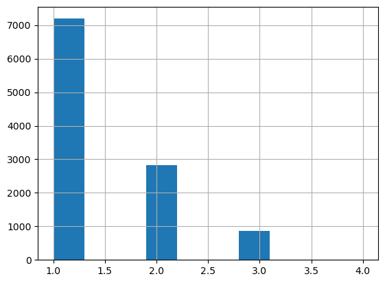

```python
train['weather'].hist()
```

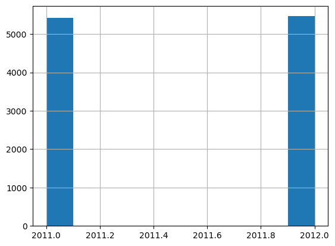

```python
train['year'].hist()
```

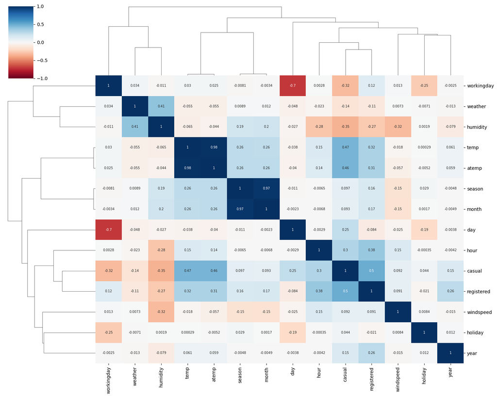

```python
import seaborn as sns
col = ['season', 'holiday', 'workingday', 'weather', 'temp', 'atemp',
       'humidity', 'windspeed', 'casual', 'registered', 'day',
       'month', 'year', 'hour']
correlation_matrix = train[col].corr()
sns.clustermap(correlation_matrix, method="complete", cmap='RdBu', annot=True,
               annot_kws={"size": 7}, vmin=-1, vmax=1, figsize=(15,12));
```

```python
train=pd.concat([train,pd.get_dummies(train['weather'],prefix='weather')],axis=1).drop(['weather'],axis=1)
```

```python
train=pd.concat([train,pd.get_dummies(train['season'],prefix='season')],axis=1).drop(['season'],axis=1)
```

```python
test.dtypes
```

```
season        category
holiday          int64
workingday       int64
weather       category
temp           float64
atemp          float64
humidity         int64
windspeed      float64
day              int32
month            int32
year             int32
hour             int32
dtype: object
```

```python
test=pd.concat([test,pd.get_dummies(test['weather'],prefix='weather')],axis=1).drop(['weather'],axis=1)
```

```python
test=pd.concat([test,pd.get_dummies(test['season'],prefix='season')],axis=1).drop(['season'],axis=1)
```

```python
test.head()
```

|  | holiday | workingday | temp | atemp | humidity | windspeed | day | month | year | hour | weather_1 | weather_2 | weather_3 | weather_4 | season_1 | season_2 | season_3 | season_4 |
| --- | --- | --- | --- | --- | --- | --- | --- | --- | --- | --- | --- | --- | --- | --- | --- | --- | --- | --- |
| 0 | 0 | 1 | 10.66 | 11.365 | 56 | 26.0027 | 3 | 1 | 2011 | 0 | True | False | False | False | True | False | False | False |
| 1 | 0 | 1 | 10.66 | 13.635 | 56 | 0.0000 | 3 | 1 | 2011 | 1 | True | False | False | False | True | False | False | False |
| 2 | 0 | 1 | 10.66 | 13.635 | 56 | 0.0000 | 3 | 1 | 2011 | 2 | True | False | False | False | True | False | False | False |
| 3 | 0 | 1 | 10.66 | 12.880 | 56 | 11.0014 | 3 | 1 | 2011 | 3 | True | False | False | False | True | False | False | False |
| 4 | 0 | 1 | 10.66 | 12.880 | 56 | 11.0014 | 3 | 1 | 2011 | 4 | True | False | False | False | True | False | False | False |

```python
train
```

|  | holiday | workingday | temp | atemp | humidity | windspeed | casual | registered | count | day | ... | year | hour | weather_1 | weather_2 | weather_3 | weather_4 | season_1 | season_2 | season_3 | season_4 |
| --- | --- | --- | --- | --- | --- | --- | --- | --- | --- | --- | --- | --- | --- | --- | --- | --- | --- | --- | --- | --- | --- |
| 0 | 0 | 0 | 9.84 | 14.395 | 81 | 0.0000 | 3 | 13 | 16 | 5 | ... | 2011 | 0 | True | False | False | False | True | False | False | False |
| 1 | 0 | 0 | 9.02 | 13.635 | 80 | 0.0000 | 8 | 32 | 40 | 5 | ... | 2011 | 1 | True | False | False | False | True | False | False | False |
| 2 | 0 | 0 | 9.02 | 13.635 | 80 | 0.0000 | 5 | 27 | 32 | 5 | ... | 2011 | 2 | True | False | False | False | True | False | False | False |
| 3 | 0 | 0 | 9.84 | 14.395 | 75 | 0.0000 | 3 | 10 | 13 | 5 | ... | 2011 | 3 | True | False | False | False | True | False | False | False |
| 4 | 0 | 0 | 9.84 | 14.395 | 75 | 0.0000 | 0 | 1 | 1 | 5 | ... | 2011 | 4 | True | False | False | False | True | False | False | False |
| ... | ... | ... | ... | ... | ... | ... | ... | ... | ... | ... | ... | ... | ... | ... | ... | ... | ... | ... | ... | ... | ... |
| 10881 | 0 | 1 | 15.58 | 19.695 | 50 | 26.0027 | 7 | 329 | 336 | 2 | ... | 2012 | 19 | True | False | False | False | False | False | False | True |
| 10882 | 0 | 1 | 14.76 | 17.425 | 57 | 15.0013 | 10 | 231 | 241 | 2 | ... | 2012 | 20 | True | False | False | False | False | False | False | True |
| 10883 | 0 | 1 | 13.94 | 15.910 | 61 | 15.0013 | 4 | 164 | 168 | 2 | ... | 2012 | 21 | True | False | False | False | False | False | False | True |
| 10884 | 0 | 1 | 13.94 | 17.425 | 61 | 6.0032 | 12 | 117 | 129 | 2 | ... | 2012 | 22 | True | False | False | False | False | False | False | True |
| 10885 | 0 | 1 | 13.12 | 16.665 | 66 | 8.9981 | 4 | 84 | 88 | 2 | ... | 2012 | 23 | True | False | False | False | False | False | False | True |

10886 rows × 21 columns

```python
train.head()
```

|  | holiday | workingday | temp | atemp | humidity | windspeed | casual | registered | count | day | ... | year | hour | weather_1 | weather_2 | weather_3 | weather_4 | season_1 | season_2 | season_3 | season_4 |
| --- | --- | --- | --- | --- | --- | --- | --- | --- | --- | --- | --- | --- | --- | --- | --- | --- | --- | --- | --- | --- | --- |
| 0 | 0 | 0 | 9.84 | 14.395 | 81 | 0.0 | 3 | 13 | 16 | 5 | ... | 2011 | 0 | True | False | False | False | True | False | False | False |
| 1 | 0 | 0 | 9.02 | 13.635 | 80 | 0.0 | 8 | 32 | 40 | 5 | ... | 2011 | 1 | True | False | False | False | True | False | False | False |
| 2 | 0 | 0 | 9.02 | 13.635 | 80 | 0.0 | 5 | 27 | 32 | 5 | ... | 2011 | 2 | True | False | False | False | True | False | False | False |
| 3 | 0 | 0 | 9.84 | 14.395 | 75 | 0.0 | 3 | 10 | 13 | 5 | ... | 2011 | 3 | True | False | False | False | True | False | False | False |
| 4 | 0 | 0 | 9.84 | 14.395 | 75 | 0.0 | 0 | 1 | 1 | 5 | ... | 2011 | 4 | True | False | False | False | True | False | False | False |

5 rows × 21 columns

```python
train.to_csv("train_proocessed.csv")
test.to_csv("test_processed.csv")
```

```python
from autogluon.common import space


non_default_options = { 'num_epochs': 100,
                       'learning_rate': space.Real(1e-4, 1e-2, default=5e-3, log=True),
                       'activation': space.Categorical('relu', 'softrelu', 'tanh'),
                        'dropout_prob': space.Real(0.0, 0.5, default=0.1),}
GBM_options = {  'extra_trees': True,
                'num_boost_round': space.Int(lower=100, upper=800, default=100),
    'num_leaves': space.Int(lower=20, upper=100, default=40),'learning_rate':0.1,
}
hyperparameters = {

                   'GBM': GBM_options,
                   'NN_TORCH': non_default_options,
                  }

hyperparameter_tune_kwargs = {
    'num_trials': 40,
    'scheduler' : 'local',
    # "scheduler": "ASHA",
    'searcher':'bayes'
}
```

```python
predictor_new_hpo_2 = TabularPredictor(label="count", problem_type="regression", eval_metric="root_mean_squared_error",
                             learner_kwargs={
                                 "ignored_columns":["casual", "registered"]}
                                    ).fit(train_data=train,time_limit=900,presets="best_quality" ,num_bag_folds = 5,hyperparameters=hyperparameters,
    hyperparameter_tune_kwargs=hyperparameter_tune_kwargs)
```

```
2024-02-01 22:16:19,247	ERROR worker.py:405 -- Unhandled error (suppress with 'RAY_IGNORE_UNHANDLED_ERRORS=1'): The worker died unexpectedly while executing this task. Check python-core-worker-*.log files for more information.
Fitted model: NeuralNetTorch_BAG_L2/b36f5aae ...
	-41.2798	 = Validation score   (-root_mean_squared_error)
	75.9s	 = Training   runtime
	0.0s	 = Validation runtime
Fitting model: WeightedEnsemble_L3 ... Training model for up to 360.0s of the 20.32s of remaining time.
	Ensemble Weights: {'NeuralNetTorch_BAG_L1/5cb94c47': 0.774, 'NeuralNetTorch_BAG_L2/b36f5aae': 0.226}
	-40.2097	 = Validation score   (-root_mean_squared_error)
	0.2s	 = Training   runtime
	0.0s	 = Validation runtime
AutoGluon training complete, total runtime = 735.1s ... Best model: "WeightedEnsemble_L3"
TabularPredictor saved. To load, use: predictor = TabularPredictor.load("AutogluonModels/ag-20240201_220403")
```

```
*** Summary of fit() ***
Estimated performance of each model:
                            model  score_val              eval_metric  pred_time_val    fit_time  pred_time_val_marginal  fit_time_marginal  stack_level  can_infer  fit_order
0             WeightedEnsemble_L3 -40.209670  root_mean_squared_error       0.001648  223.999723                0.000955           0.197569            3       True          4
1  NeuralNetTorch_BAG_L1/5cb94c47 -40.302512  root_mean_squared_error       0.000165  147.907153                0.000165         147.907153            1       True          1
2             WeightedEnsemble_L2 -40.302512  root_mean_squared_error       0.001578  147.916565                0.001413           0.009412            2       True          2
3  NeuralNetTorch_BAG_L2/b36f5aae -41.279802  root_mean_squared_error       0.000693  223.802154                0.000528          75.895000            2       True          3
Number of models trained: 4
Types of models trained:
{'StackerEnsembleModel_TabularNeuralNetTorch', 'WeightedEnsembleModel'}
Bagging used: True  (with 5 folds)
Multi-layer stack-ensembling used: True  (with 3 levels)
Feature Metadata (Processed):
(raw dtype, special dtypes):
('float', [])     :  3 | ['temp', 'atemp', 'windspeed']
('int', [])       :  4 | ['humidity', 'day', 'month', 'hour']
('int', ['bool']) : 11 | ['holiday', 'workingday', 'year', 'weather_1', 'weather_2', ...]
```

```
*** End of fit() summary ***
```

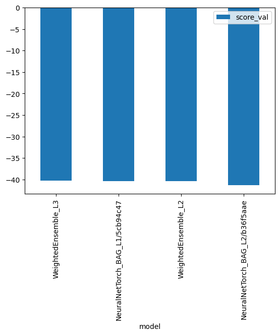

```python
predictor_new_hpo_2.fit_summary()
predictor_new_hpo_2.leaderboard(silent=True).plot(kind="bar", x="model", y="score_val")
```

```python
# Remember to set all negative values to zero
predictor_new_hpo_2_count = predictor_new_hpo_2.predict(test)
predictor_new_hpo_2_count.head()

count_negatives = 0
for i in range(len(predictor_new_hpo_2_count)):
    if predictor_new_hpo_2_count[i]<0:
        predictor_new_hpo_2_count[i] = 0
        count_negatives += 1
    else:
        pass
print("Negative Values Convered to zero: ",count_negatives)
```

```
Negative Values Convered to zero:  0
```

```python
# Same submitting predictions
submission_new_hpo2 = pd.read_csv("sampleSubmission.csv")
submission_new_hpo2["count"] = predictor_new_hpo_2_count
submission_new_hpo2.to_csv("submission_new_hpo_2.csv", index=False)
```

```python
!kaggle competitions submit -c bike-sharing-demand -f submission_new_hpo_2.csv -m "new submission with hyperparameters 3 re running whole notebook"
```

```python
!kaggle competitions submit -c bike-sharing-demand -f submission_new_hpo_2.csv -m "new submission with hyperparameters 3"
```

```
Successfully submitted to Bike Sharing Demand
```